# ggplot2 : 10. Using Colors in Plots

```r
# install.packages(c('ggplot2’, 'gcookbook’), dependencies = TRUE)
library(ggplot2)
library(gcookbook)
```

## Setting the Colors of Objects

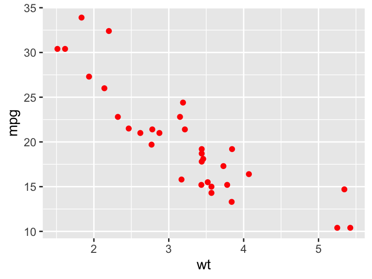

```r
ggplot(mtcars, aes(x = wt, y = mpg)) + geom_point(color = 'red')
```

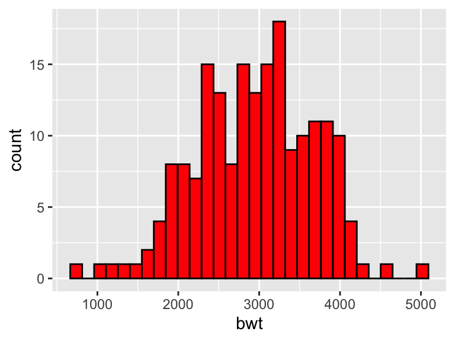

```r
library(MASS)
ggplot(birthwt, aes(x = bwt)) + geom_histogram(fill = 'red', color = 'black')
```

## Mapping Variables to Colors

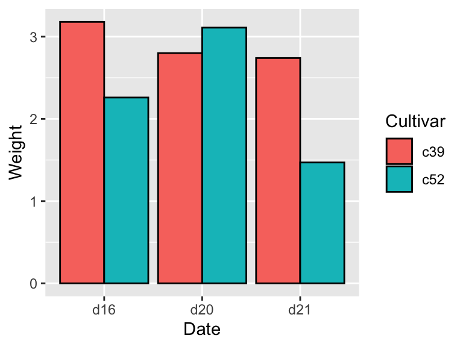

```r
# method 1 - "fill" in "aes()"
ggplot(cabbage_exp, aes(x = Date, y = Weight, fill = Cultivar)) +
  geom_col(color = 'black', position = 'dodge')
```

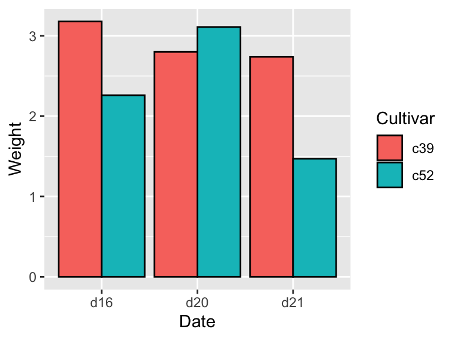

```r
# method 2 - "aes( fill = )" in "geom"
ggplot(cabbage_exp, aes(x = Date, y = Weight)) +
  geom_col(aes(fill = Cultivar), color = 'black', position = 'dodge')
```

- fill 변수 지정은 `ggplot()` 내에 `aes()` 함수에서 혹은 `geom()` 함수 내에 `aes()` 함수에서 이루어지며 효과는 동일하다.
- 코드의 재사용성을 위해서는 `ggplot()` 내에 `fill` 변수를 정의하고 그래픽의 효과를 나타내는 옵션들을 `geom()` 함수에 정의하는 것이 일관성이 있으며 효율적이다.

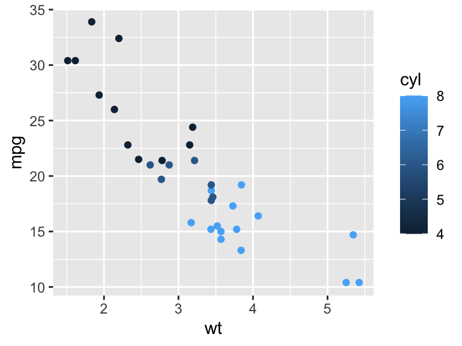

```r
# method 1
ggplot(mtcars, aes(x = wt, y = mpg, color = cyl)) + geom_point()
```

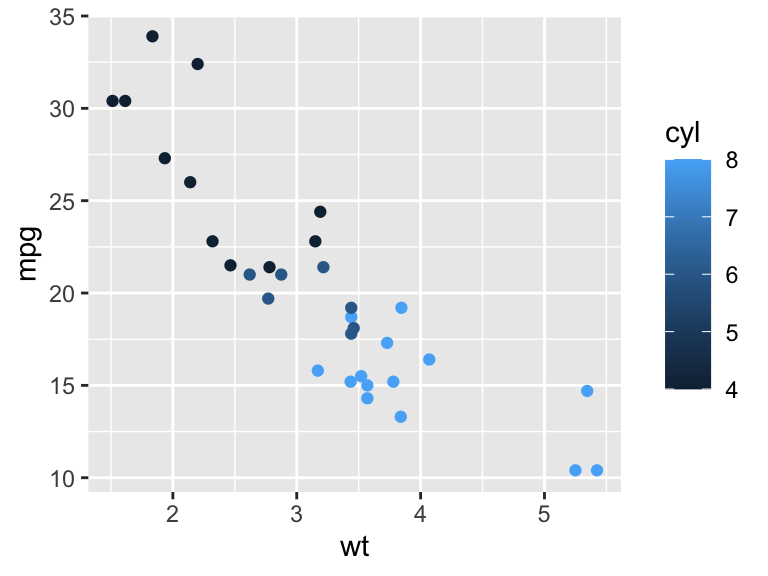

```r
# method 2
ggplot(mtcars, aes(x = wt, y = mpg)) + geom_point(aes(color = cyl))
```

- color 변수 지정의 예. 두 경우 동일한 결과를 줌.

## Using a Different Palette for a Discrete Variable

```r
str(uspopage)
```

```
## 'data.frame':    824 obs. of  3 variables:
##  $ Year     : int  1900 1900 1900 1900 1900 1900 1900 1900 1901 1901 ...
##  $ AgeGroup : Factor w/ 8 levels "<5","5-14","15-24",..: 1 2 3 4 5 6 7 8 1 2 ...
##  $ Thousands: int  9181 16966 14951 12161 9273 6437 4026 3099 9336 17158 ...
```

```r
p <- ggplot(uspopage, aes(x = Year, y = Thousands, fill = AgeGroup)) + geom_area()
p
```

[output not shown]

```r
p + scale_fill_discrete()
```

[output not shown]

```r
p + scale_fill_hue()
```

[output not shown]

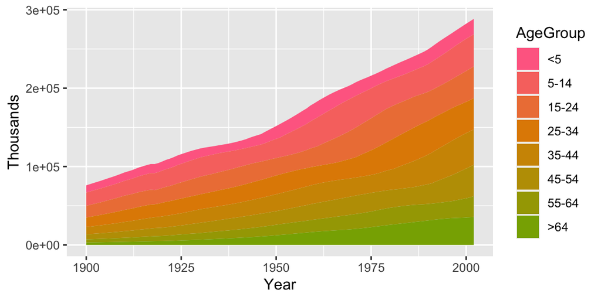

```r
p + scale_fill_hue(h = c(0, 100))
```

- area plot에 적용되는 색상을 `scale_fill_discrete()` 혹은 `scale_fill_hue()` 함수 적용.
- `scale_fill_hue(h = c(0, 100))` : 0부터 100까지 범위를 fill 변수의 변수값 갯수로 균등분할하여 해당 변수값에 대응하는 색상을 적용함. 디폴트 영역은 h = c(0, 360) 임.

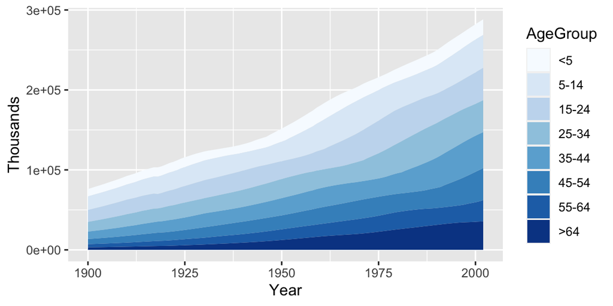

```r
p <- ggplot(uspopage, aes(x = Year, y = Thousands, fill = AgeGroup)) + geom_area()
p + scale_fill_brewer()
```

- `scale_fill_brewer()` 적용의 예. 디폴트 palette는 ‘Blues’임.

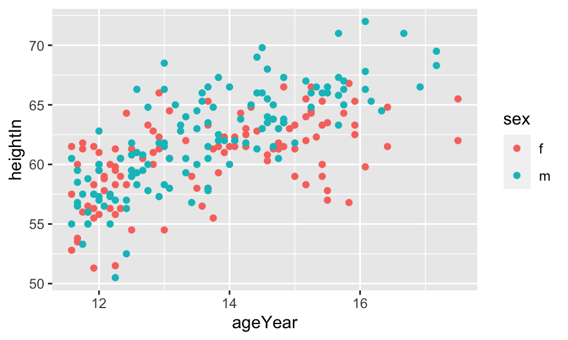

```r
h <- ggplot(heightweight, aes(x = ageYear, y = heightIn, color = sex)) +
    geom_point()
h
```

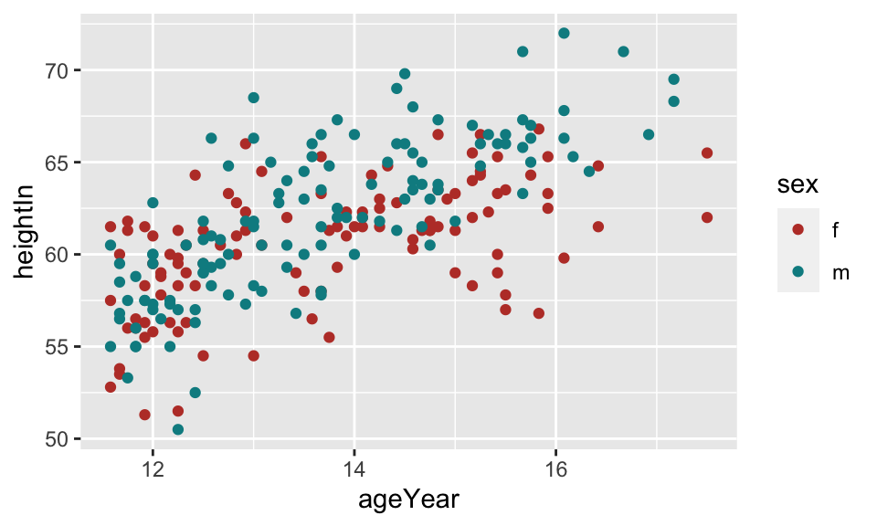

```r
h + scale_color_hue(l = 45)
```

- hue의 밝기 조정의 예. `l = 65`가 디폴트임. 작은 수는 어둡게, 큰 수는 밝게 함. 범위는 [0, 100] 사이임.

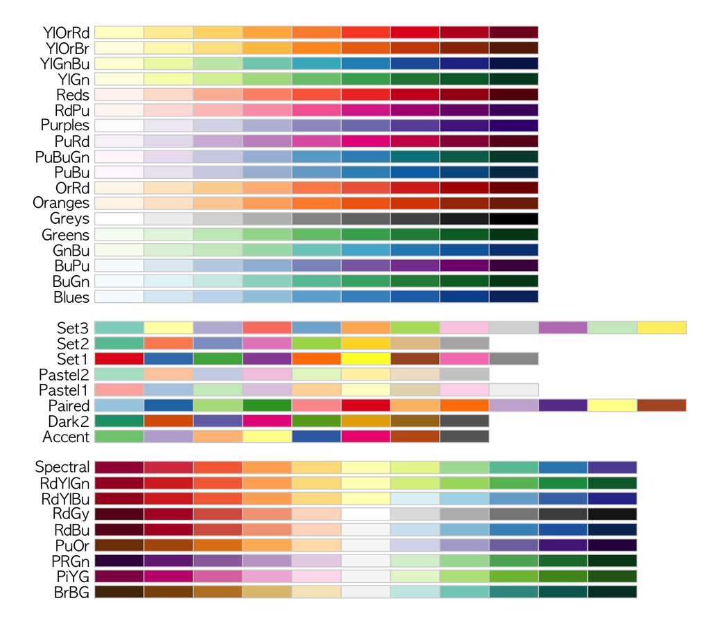

```r
library(RColorBrewer)
par(mar = c(0, 4, 0, 0))
display.brewer.all()
```

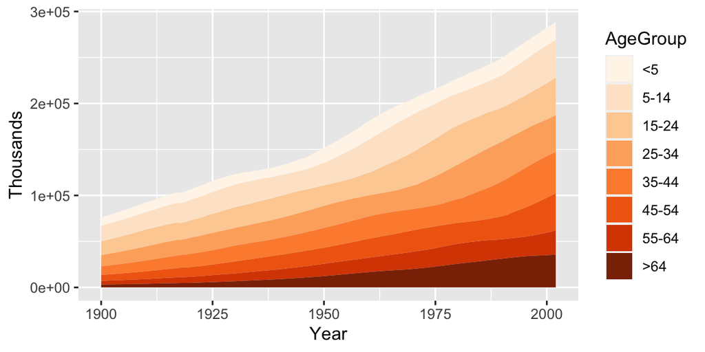

```r
p + scale_fill_brewer(palette = 'Oranges')
```

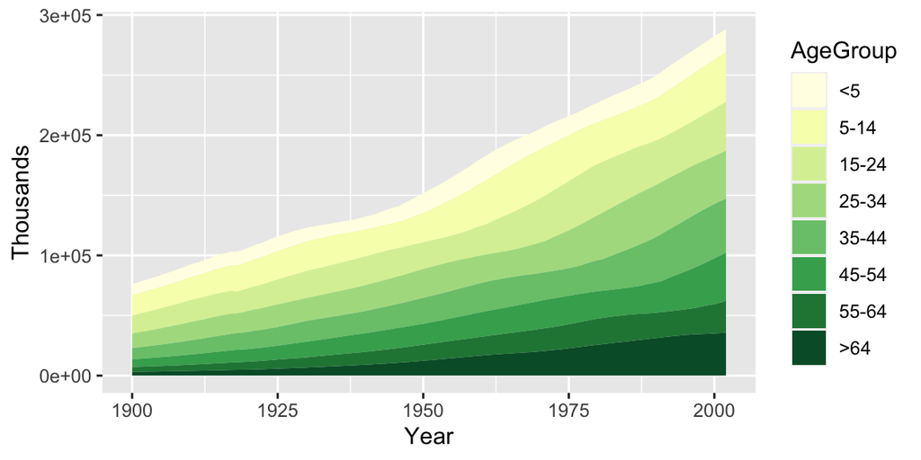

```r
p + scale_fill_brewer(palette = 'YlGn')
```

- ColorBrewer에서 정의된 palette를 이용한 예.

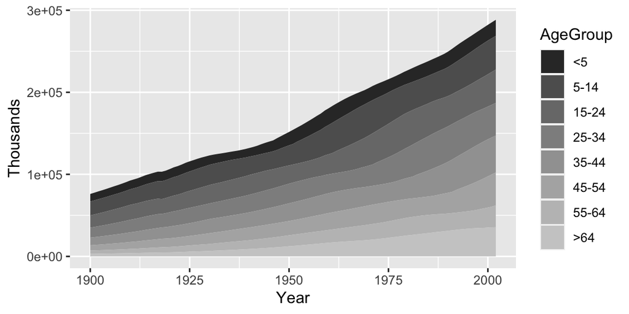

```r
p + scale_fill_grey()
```

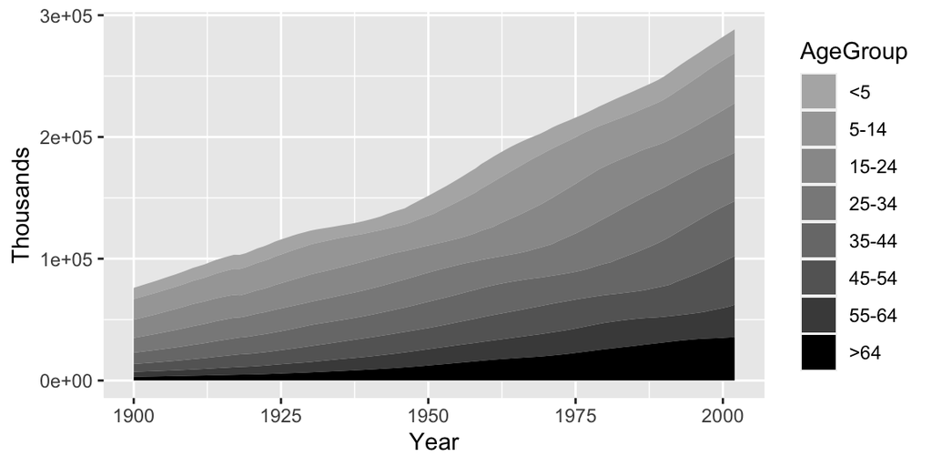

```r
p + scale_fill_grey(start = 0.7, end = 0)
```

- `scale_fill_grey()` 적용의 예.
- 디폴트는 start=0.2 (어두움), end=0.8 (밝음).
- start 값은 end 값보다 크게 하면 밝기는 밝음에서 어두움 순서로 바뀜.
- start 및 end 값은 [0, 1] 사이에서 지정.

## Using a Manually Defined Palette for a Discrete Variable

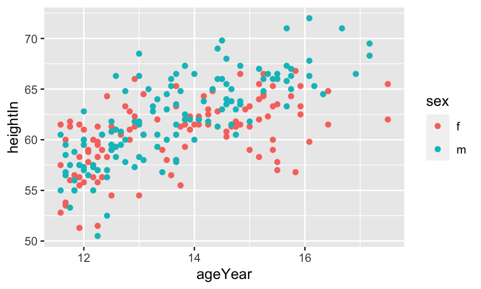

```r
h <- ggplot(heightweight, aes(x = ageYear, y = heightIn, color = sex)) +
    geom_point()
h
```

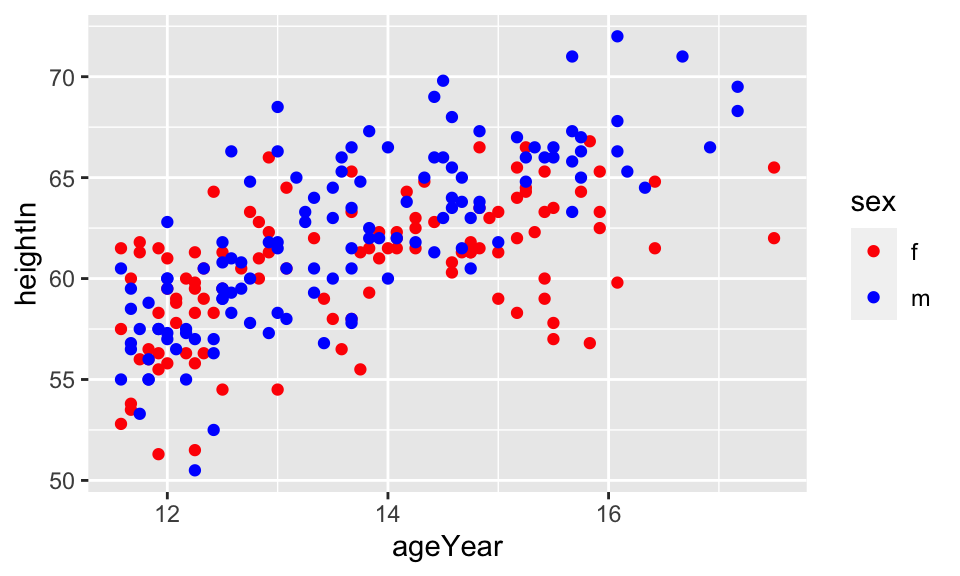

```r
h + scale_color_manual(values = c('red', 'blue'))
```

- `scale_color_manual()` 을 이용하여 color name을 지정하여 색상을 정하는 방법의 예.

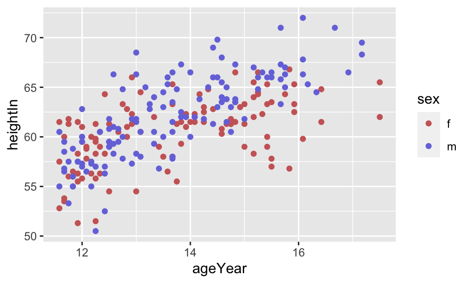

```r
h <- ggplot(heightweight, aes(x = ageYear, y = heightIn, color = sex)) +
    geom_point()
h + scale_color_manual(values = c('#CC6666', '#7777DD'))
```

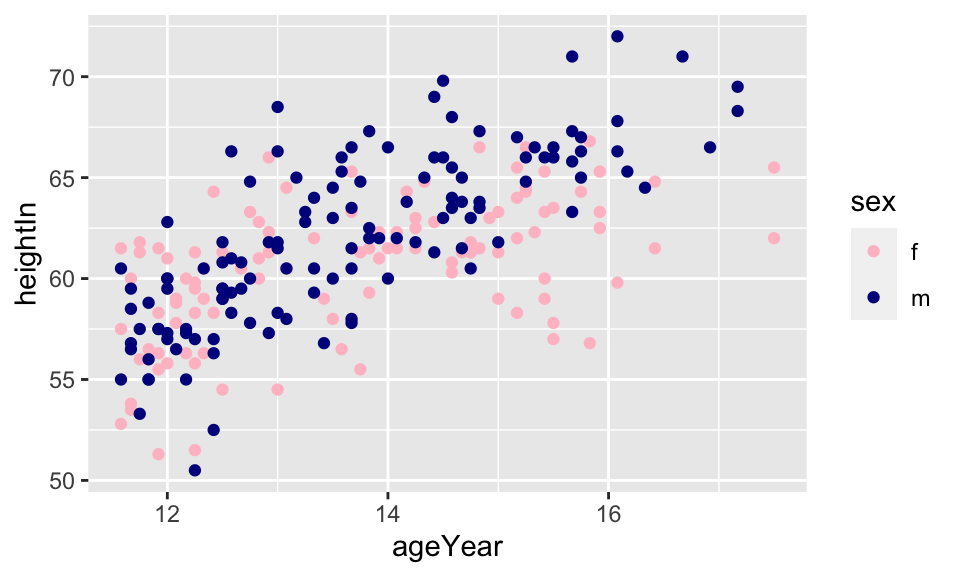

```r
h + scale_color_manual(values = c(m = 'darkblue', f = 'pink'))
```

```r
colors()
```

```
##   [1] "white"                "aliceblue"            "antiquewhite"
##   [4] "antiquewhite1"        "antiquewhite2"        "antiquewhite3"
##   [7] "antiquewhite4"        "aquamarine"           "aquamarine1"
##  [10] "aquamarine2"          "aquamarine3"          "aquamarine4"
##  [13] "azure"                "azure1"               "azure2"
##  [16] "azure3"               "azure4"               "beige"
##  [19] "bisque"               "bisque1"              "bisque2"
##  [22] "bisque3"              "bisque4"              "black"
##  [25] "blanchedalmond"       "blue"                 "blue1"
##  [28] "blue2"                "blue3"                "blue4"
##  [31] "blueviolet"           "brown"                "brown1"
##  [34] "brown2"               "brown3"               "brown4"
##  [37] "burlywood"            "burlywood1"           "burlywood2"
##  [40] "burlywood3"           "burlywood4"           "cadetblue"
##  [43] "cadetblue1"           "cadetblue2"           "cadetblue3"
```

[output cut: 204 more lines]

- `scale_color_manual()` 을 이용하여 RBG 색상 지정 가능.
- `values = c(m = ‘darkblue’, f = ‘pink’)` : 그룹 변수의 변수값에 대응하는 색상을 지정할 수 있음.
- R에서 사용되는 색상이름은 `colors()` 를 통해 확인 가능.

## Using a Manually Defined Palette for a Continuous Variable

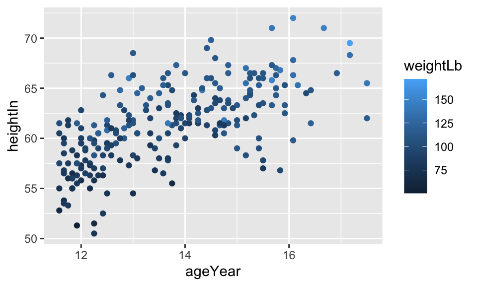

```r
p <- ggplot(heightweight, aes(x = ageYear, y = heightIn, color = weightLb)) +  geom_point(size = 1.5)
p
```

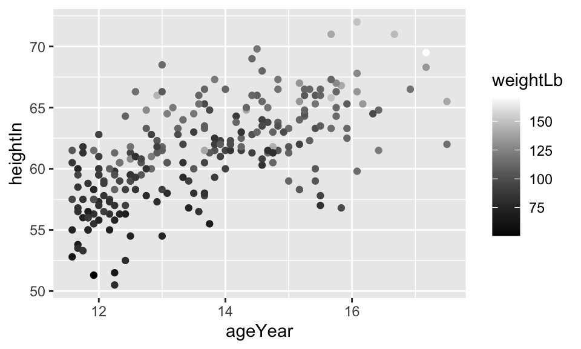

```r
p + scale_color_gradient(low = 'black', high = 'white')
```

- `scale_color_gradient(low = ‘black’, high = ‘white’)` : 연속형으로 주어진 color 변수에 대해 낮은 변수값에 대해 black, 높은 변수값에 대해 white를 주고 사이값에 대해서는 두 색상의 중간색으로 주어짐.
- 디폴트는 low=‘#132B43’, high=‘#56B1F7’으로 주어짐.

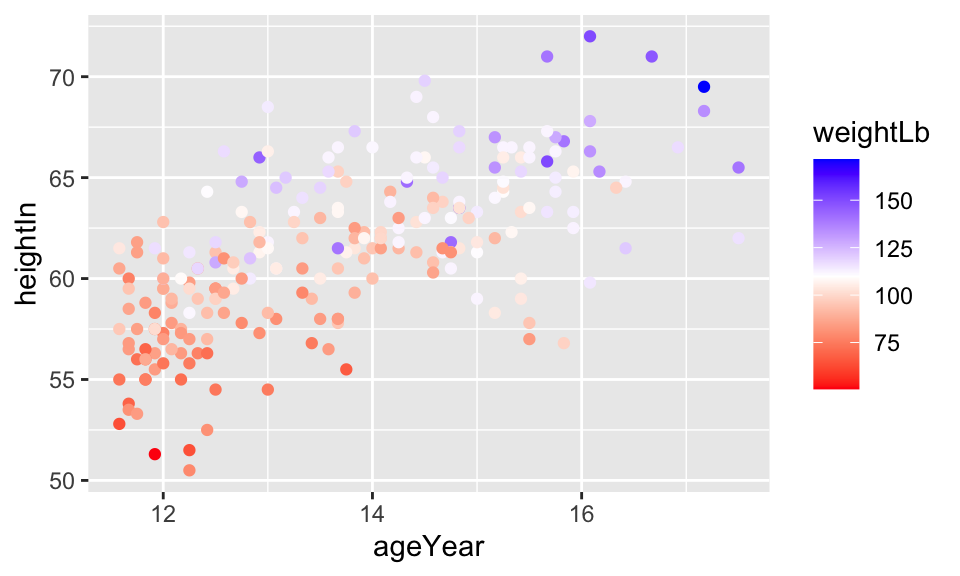

```r
p + scale_color_gradient2(low = 'red', mid = 'white', high = 'blue', midpoint = 110)
```

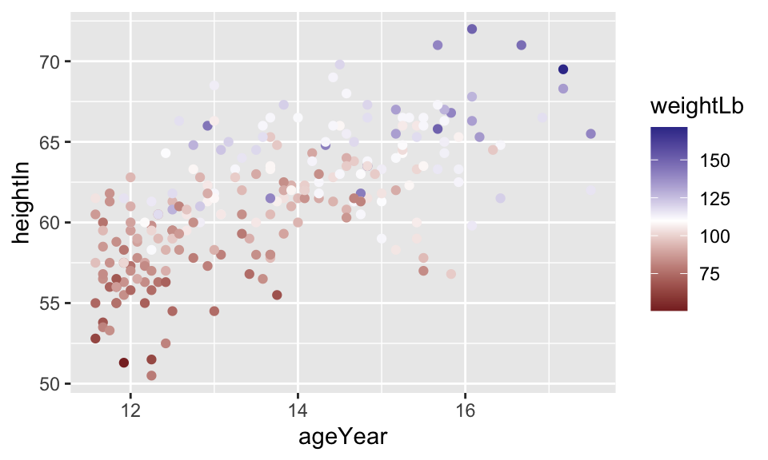

```r
library(scales) # "muted()" for a less-saturated version
p + scale_color_gradient2(low = muted('red'), mid = 'white', high = muted('blue'), midpoint = 110)
```

- `scale_color_gradient2(low = ‘red’, mid = ‘white’, high = ‘blue’, midpoint = 110)` : 연속형으로 주어진 color 변수에 대해 낮은 변수값에 대해 red, 높은 변수값에 대해 blue주고 중간값에 대해서는 white를 주어짐. 중간값으로는 110으로 지정.
- `muted(colour, l = 30, c = 70)` : 주어진 색상에 대해 명도(luminance) 및 채도(chroma)를 조정하여 RGB 형식으로 출력. scales 패키지에서 제공함.

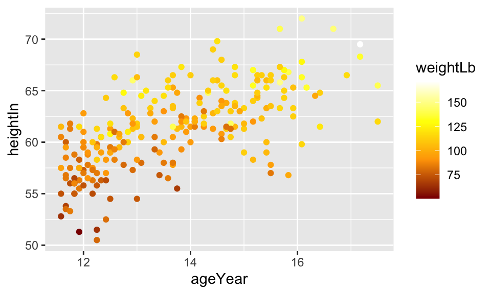

```r
p + scale_color_gradientn(colours = c('darkred', 'orange', 'yellow', 'white'))
```

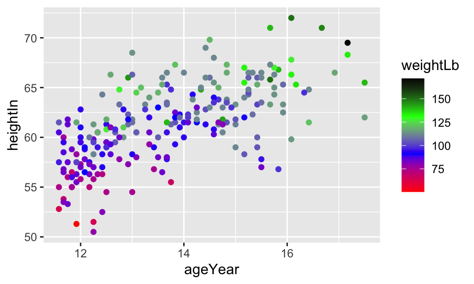

```r
p + scale_color_gradientn(colours = c('red', 'blue', 'green', 'black'))
```